# Exploring Starry Realms in the Milky Way with Gaia

# 5. A small fun project

Writing an ADQL query to get the following parameters of the 10,000 closest stars in csv format

- BP - RP color (bp_rp in the Gaia database)
- absolute g-band photometric magnitude (to be calculated)
- distance
- RA
- Dec
- radius
- effective temprature

### Hints:

- Distance (in parsecs) is the inverse of parallax (in arcseconds). Keep an eye on units! Gaia by default shows parallaxes in milliarcseconds (mas) .
- bp_rp tells us the blue photometer and red photometer values, and effectively, the color of the stars.
- absolute photometric magnitude in the gband tells us the brightness of these stars
- You can calculate absolute photometric magnitude in the gband using this formula: phot_g_mean_mag + 5 + 5 * log10(parallax/1000)
- Find the names of the colums for RA, Dec, radius and effective temparature using the database window part in the *Advanced (ADQL)* tab in *'Search'* of the Gaia archive
- Some Gaia sources have negative parallaxes due to instrumental imperfections. You'll need to add a line to your query specifying that parallax must be greater than 0.

### 5.1 SQL Query

```
SELECT TOP 10000
    phot_g_mean_mag + 5 * log10(parallax/1000) + 5 AS g_abs, bp_rp, 1/(parallax/1000) AS dist,
    ra, dec, radius_val, teff_val
FROM gaiadr2.gaia_source
WHERE parallax > 0
ORDER BY parallax DESC
```

## 5.2 Plotting the data

### 5.2.1 Color Magnitude Plot (Simple)

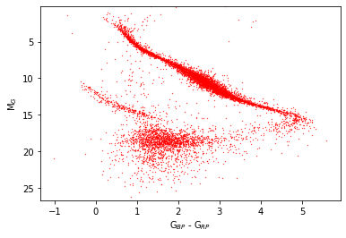

```python
data = pd.read_csv('data/closest10k_stars.csv')

plt.figure()
plt.scatter(data.bp_rp, data.g_abs, s=.1, color='red')

# Reverse the direction of the y axis. Max and Min of g_abs are used for the limits in y-axis
plt.ylim(max(data.g_abs),min(data.g_abs))

plt.xlabel('G$_{BP}$ - G$_{RP}$')
plt.ylabel('M$_G$')
plt.show()
```

### 5.2.2 Colored HR Diagram

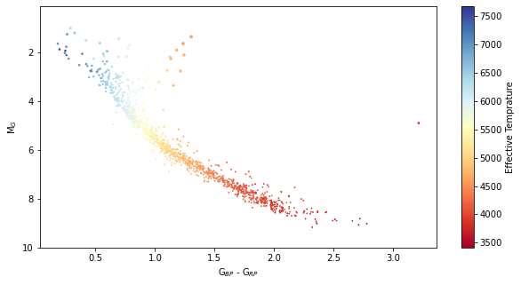

```python
plt.figure(figsize = (10, 5))
# Using size as radius, color as effective temprature, and colormap RdYlBu (for mapping with star colors)
plt.scatter(data.bp_rp, data.g_abs,
            s=data.radius_val, c=data.teff_val,
            cmap='RdYlBu')
plt.colorbar(label='Effective Temprature') # For the colorbar to appear
plt.ylim(10 ,min(data.g_abs)) #Reversing the y-axis
plt.xlabel('G$_{BP}$ - G$_{RP}$')
plt.ylabel('M$_G$')
plt.show()
```

### 5.2.3 A 3D plot of the stars

Plot the scatter graph using RA, Dec and distance. A colormap of Red-Yellow-Blue scale is used with sizes s given by stellar radiix10, color c given by stellar effective temperature

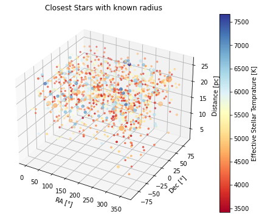

```python
# Magic command for interactive 3D plots: %matplotlib notebook
%matplotlib inline
fig=plt.figure(figsize = (10, 6))
ax = plt.axes(projection ="3d")
scatter_plot=ax.scatter3D(data.ra, data.dec, data.dist, s=data.radius_val*10,
                          c=data.teff_val, cmap='RdYlBu')
ax.set_xlabel('RA [$\degree$]')
ax.set_ylabel('Dec [$\degree$]')
ax.set_zlabel('Distance [pc]')
plt.title('Closest Stars with known radius')
fig.colorbar(scatter_plot, label="Effective Stellar Temprature [K]")
```

# 6 *GaiaCurves*

- An open-source package to fetch light curves of variable stars from Gaia Data Releases (1 and 2) with a star name that can be resolved by SIMBAD
- Installation `pip install GaiaCurves`
- Github: github.com/sonithls/GaiaCurves

## Demo

```python
from GaiaCurves import gaia_lightcurve as gc
star='NQ Dra'
curves=gc.fetch_curves([star], output_dir = './data/')
print(curves)
```

```
{'NQ Dra': {'ID': '2154100169676165120', 'pathname': './data/2154100169676165120_data_dr2.csv', 'source': 'DR2'}}
```

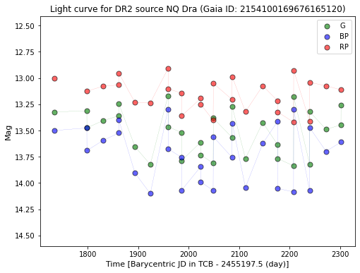

```python
%matplotlib inline
gc.plot_lightcurve(curves[star]['pathname'], star, curves[star]['ID'])
```

# Thank you for listening!

## Questions?

### Find me on sites.google.com/view/chetanchawla

[figure not shown]